# Assigment 3: US Hospital Quality Comparison

The best hints of this assignment is to get real data from internet to compare heart failure, heart attack and pneumonia results from all the hospitals in the US.

### Introduction

Download the file ProgAssignment3-data.zip file containing the data for Programming Assignment 3 from the Coursera web site. Unzip the file in a directory that will serve as your working directory. When you start up R make sure to change your working directory to the directory where you unzipped the data. The data for this assignment come from the Hospital Compare web site (http://hospitalcompare.hhs.gov) run by the U.S. Department of Health and Human Services. The purpose of the web site is to provide data and information about the quality of care at over 4,000 Medicare-certified hospitals in the U.S. This dataset essentially covers all major U.S. hospitals. This dataset is used for a variety of purposes, including determining whether hospitals should be fined for not providing high quality care to patients (see http://goo.gl/jAXFX for some background on this particular topic). The Hospital Compare web site contains a lot of data and we will only look at a small subset for this assignment. The zip file for this assignment contains three files

- outcome-of-care-measures.csv: Contains information about 30-day mortality and readmission rates for heart attacks, heart failure, and pneumonia for over 4,000 hospitals.
- hospital-data.csv: Contains information about each hospital.
- Hospital_Revised_Flatfiles.pdf: Descriptions of the variables in each file (i.e the code book).

A description of the variables in each of the files is in the included PDF file named Hospital_Revised_Flatfiles.pdf. This document contains information about many other files that are not included with this programming assignment. You will want to focus on the variables for Number 19 (“Outcome of Care Measures.csv”) and Number 11 (“Hospital Data.csv”). You may find it useful to print out this document (at least the pages for Tables 19 and 11) to have next to you while you work on this assignment. In particular, the numbers of the variables for each table indicate column indices in each table (i.e. “Hospital Name” is column 2 in the outcome-of-care-measures.csv file).

1. Plot the 30-day mortality rates for heart attack, heart failure and pneumonia

Read the outcome data into R via the read.csv function and look at the ???rst few rows.

```r
outcome <- read.csv("outcome-of-care-measures.csv", colClasses = "character")
head(outcome[,c(2,3,6,7,11,17,23)])
```

```
##                      Hospital.Name                  Address.1         City
## 1 SOUTHEAST ALABAMA MEDICAL CENTER     1108 ROSS CLARK CIRCLE       DOTHAN
## 2    MARSHALL MEDICAL CENTER SOUTH 2505 U S HIGHWAY 431 NORTH         BOAZ
## 3   ELIZA COFFEE MEMORIAL HOSPITAL         205 MARENGO STREET     FLORENCE
## 4         MIZELL MEMORIAL HOSPITAL              702 N MAIN ST          OPP
## 5      CRENSHAW COMMUNITY HOSPITAL        101 HOSPITAL CIRCLE      LUVERNE
## 6    MARSHALL MEDICAL CENTER NORTH    8000 ALABAMA HIGHWAY 69 GUNTERSVILLE
##   State Hospital.30.Day.Death..Mortality..Rates.from.Heart.Attack
## 1    AL                                                      14.3
## 2    AL                                                      18.5
## 3    AL                                                      18.1
## 4    AL                                             Not Available
## 5    AL                                             Not Available
## 6    AL                                             Not Available
##   Hospital.30.Day.Death..Mortality..Rates.from.Heart.Failure
## 1                                                       11.4
## 2                                                       15.2
## 3                                                       11.3
## 4                                                       13.6
## 5                                                       13.8
## 6                                                       12.5
##   Hospital.30.Day.Death..Mortality..Rates.from.Pneumonia
## 1                                                   10.9
## 2                                                   13.9
## 3                                                   13.4
## 4                                                   14.9
## 5                                                   15.8
## 6                                                    8.7
```

There are many columns in this dataset. You can see how many by typing ncol(outcome) (you can see the number of rows with the nrow function). In addition, you can see the names of each column by typing names(outcome) (the names are also in the PDF document.

To make a simple histogram of the 30-day death rates from heart attack (column 11 in the outcome dataset)

```r
HeartAttack30dayDeathRate <- as.numeric(outcome[, 11])
HeartFailure30dayDeathRate <- as.numeric(outcome[, 17])
Pneumonia30dayDeathRate <- as.numeric(outcome[, 23])
```

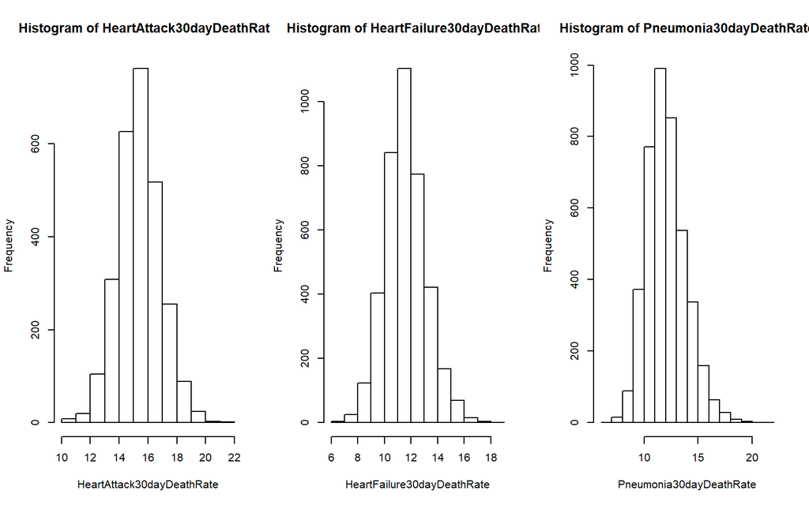

```r
## You may get a warning about NAs being introduced; that is okay hist(outcome[, 11])
par(mfrow=c(1,3))
hist(HeartAttack30dayDeathRate)
hist(HeartFailure30dayDeathRate)
hist(Pneumonia30dayDeathRate)
```

2. Finding the best hospital in a state

Write a function called best that take two arguments: the 2-character abbreviated name of a state and an outcome name. The function reads the outcome-of-care-measures.csv ???le and returns a character vector with the name of the hospital that has the best (i.e. lowest) 30-day mortality for the speci???ed outcome in that state. The hospital name is the name provided in the Hospital.Name variable. The outcomes can be one of “heart attack”, “heart failure”, or “pneumonia”. Hospitals that do not have data on a particular outcome should be excluded from the set of hospitals when deciding the rankings. Handling ties. If there is a tie for the best hospital for a given outcome, then the hospital names should be sorted in alphabetical order and the ???rst hospital in that set should be chosen (i.e. if hospitals “b”, “c”, and “f” are tied for best, then hospital “b” should be returned).

```r
best <- function(state, outcome) {
  library(dplyr)
  ## Read outcome data
  if (!file.exists("outcome-of-care-measures.csv"))
      stop('file outcome-of-care-measures.csv  not present')
  file <- read.csv("outcome-of-care-measures.csv", colClasses = "character")
  ## Check that state and outcome are valid
  valid <- any(state==file$State)
  if (valid==FALSE)
    stop(' invalid state')
  valid <- any(outcome==c('heart attack','heart failure','pneumonia'))
  if (valid==FALSE)
   stop(' invalid outcome')
  ## Return hospital name in that state with lowest 30-day death rate
  if (outcome=="heart attack")
    outcome = "Hospital.30.Day.Death..Mortality..Rates.from.Heart.Attack"
  if (outcome=="heart failure")
    outcome = "Hospital.30.Day.Death..Mortality..Rates.from.Heart.Failure"
  if (outcome=="pneumonia")
    outcome = "Hospital.30.Day.Death..Mortality..Rates.from.Pneumonia"

  data <- select(file,Hospital.Name,State,outcome)
  data[,3] <- suppressWarnings(as.numeric(data[,3]))
  data <- data[!is.na(data[,3]),]
  data <- filter(data,State ==state)
  ## return data
  data$Hospital.Name[which.min(data[, 3])]
}

best('AL','pneumonia')
```

```
## [1] "MARSHALL MEDICAL CENTER NORTH"
```

3. Ranking hospitals by outcome in a state

```r
library(dplyr)
rankhospital <- function(state, outcome, num = "best") {
  ## Read outcome data
  if (!file.exists("outcome-of-care-measures.csv"))
    stop('file outcome-of-care-measures.csv  not present')
  file <- read.csv("outcome-of-care-measures.csv", colClasses = "character")
  ## Check that state and outcome are valid
  valid <- any(state==file$State)
  if (valid==FALSE)
    stop(' invalid state')
  valid <- any(outcome==c('heart attack','heart failure','pneumonia'))
  if (valid==FALSE)
    stop(' invalid outcome')
  ## Return hospital name in that state with lowest 30-day death rate
  if (outcome=="heart attack")
    outcome = "Hospital.30.Day.Death..Mortality..Rates.from.Heart.Attack"
  if (outcome=="heart failure")
    outcome = "Hospital.30.Day.Death..Mortality..Rates.from.Heart.Failure"
  if (outcome=="pneumonia")
    outcome = "Hospital.30.Day.Death..Mortality..Rates.from.Pneumonia"
  data <- select(file,Hospital.Name,State,outcome)
  data[,3] <- suppressWarnings(as.numeric(data[,3]))
  data <- data[!is.na(data[,3]),]
  data <- filter(data,State ==state)
  data <- arrange(data,data[,3])

  if (class(num)=="numeric"){
    if (num<1 | num > nrow(data))
      return(NA)
  }
  if (class(num)=="character"){
    valid <- any(num==c('best','worst'))
    if (valid==FALSE)
      stop(' invalid num')
    if (num=='best') num <- 1
    if (num=='worst') num <- nrow(data)
  }
  data <- data[order(data[,3],data[,1]),]
  data[num,1]
}


rankhospital('AL','pneumonia')
```

```
## [1] "MARSHALL MEDICAL CENTER NORTH"
```

4. Ranking hospitals in all states

Write a function called rankall that takes two arguments: an outcome name (outcome) and a hospital ranking (num). The function reads the outcome-of-care-measures.csv ???le and returns a 2-column data frame containing the hospital in each state that has the ranking speci???ed in num. For example the function call rankall(“heart attack”, “best”) would return a data frame containing the names of the hospitals that are the best in their respective states for 30-day heart attack death rates. The function should return a value for every state (some may be NA). The ???rst column in the data frame is named hospital, which contains the hospital name, and the second column is named state, which contains the 2-character abbreviation for the state name. Hospitals that do not have data on a particular outcome should be excluded from the set of hospitals when deciding the rankings. Handling ties. The rankall function should handle ties in the 30-day mortality rates in the same way that the rankhospital function handles ties.

```r
library(dplyr)
rankall <- function(outcome, num = "best") {
  ## Read outcome data
  if (!file.exists("outcome-of-care-measures.csv"))
    stop('file outcome-of-care-measures.csv  not present')
  file <- read.csv("outcome-of-care-measures.csv", colClasses = "character")
  ## Check that state and outcome are valid
  valid <- any(outcome==c('heart attack','heart failure','pneumonia'))
  if (valid==FALSE)
    stop(' invalid outcome')

  if (class(num)=="numeric"){
    if (num<1 | num > nrow(data))
      return(NA)
  }
  if (class(num)=="character"){
    valid <- any(num==c('best','worst'))
    if (valid==FALSE)
      stop(' invalid num')
    if (num=='best') num <- 1
    if (num=='worst') num <- nrow(data)
  }
  ## Return hospital name in that state with lowest 30-day death rate
  if (outcome=="heart attack")
    result <- file %>% group_by(State)%>%arrange(Hospital.30.Day.Death..Mortality..Rates.from.Heart.Attack)%>%filter(row_number()==num)%>%select(Hospital.Name,State)%>%arrange(State)
  if (outcome=="heart failure")
    result <- file %>% group_by(State)%>%arrange(Hospital.30.Day.Death..Mortality..Rates.from.Heart.Failure)%>%filter(row_number()==num)%>%select(Hospital.Name,State)%>%arrange(State)
  if (outcome=="pneumonia")
    result <- file %>% group_by(State)%>%arrange(Hospital.30.Day.Death..Mortality..Rates.from.Pneumonia)%>%filter(row_number()==num)%>%select(Hospital.Name,State)%>%arrange(State)

  result <- rename(result, hospital = Hospital.Name, state = State)
  return(result)
}

rankall('pneumonia')
```

```
## # A tibble: 54 x 2
## # Groups:   state [54]
##    hospital                                           state
##    <chr>                                              <chr>
##  1 PROVIDENCE ALASKA MEDICAL CENTER                   AK
##  2 MARION REGIONAL MEDICAL CENTER                     AL
##  3 BAPTIST HEALTH MEDICAL CENTER NORTH LITTLE ROCK    AR
##  4 JOHN C LINCOLN NORTH MOUNTAIN HOSPITAL             AZ
##  5 HOLLYWOOD PRESBYTERIAN MEDICAL CENTER              CA
##  6 UNIVERSITY OF COLORADO HOSPITAL ANSCHUTZ INPATIENT CO
##  7 WILLIAM W BACKUS HOSPITAL                          CT
##  8 HOWARD UNIVERSITY HOSPITAL                         DC
##  9 BEEBE MEDICAL CENTER                               DE
## 10 SHANDS HOSPITAL AT THE UNIVERSITY OF FLORIDA       FL
## # ... with 44 more rows
```

Miguel Angel Huerta

10 de marzo de 2019